# Notes for 16S `dada2` on HPC for AVCA-ElkLD project

Lia Ossanna

2023-01-09

## Background

- Total of 69 samples to process:
  - 62 soil samples
  - 7 blanks (4 DNA extraction blanks, 2 blanks from sequencing, and one “unsigned” file)
- Samples were sequenced at the [UA Microbiome Core](https://peds.arizona.edu/steele/microbiome-core) and demultiplexed using `idemp` (see `Notes_idemp_HPC.html` document for instruction).
- These are annotated notes of the `DADA2` pipeline detailed in [this tutorial](https://benjjneb.github.io/dada2/tutorial.html) (tutorial v1.16) for filtering and trimming sequences, merging pair-ends, and constructing the ASV table and taxonomy tables. Comments about the code are written beneath the corresponding chunk.

## High performance computing (HPC)

- This code was run on the UA HPC Puma server through an interactive RStudio session with 94 cores, and a default 5 gb of RAM per core. See the [UA HPC guide](https://public.confluence.arizona.edu/display/UAHPC/User+Guide), and access UA HPC servers at https://ood.hpc.arizona.edu/.
- Run entirely on HPC server, but in multiple sessions.
- R objects (`.RData`) generated were saved at intermediate steps because a single file was too large (the server tends to crash when the `.RData` file is >10 GB), and because the script was run in multiple sessions. Steps to save intermediate work are noted and discussed.
- I have later realized that you don’t actually have to run it in an interactive session and could theoretically just submit the entire script as a job, but then you can’t see intermediate output.

## Getting ready

### Load required packages

```r
library(dada2)
```

- Used `dada` version `1.16.0`.

### Set working directory

```r
# Set working directory
setwd("/groups/egornish/lossanna/AVCA-ElkLD_16S/raw_data/16S_demultiplexed/")
```

- All the demultiplexed FASTQ files were transferred onto my HPC account using FileZilla Pro (without SSH).

### Define working folder path

```r
# Define working folder path
path <- "/groups/egornish/lossanna/AVCA-ElkLD_16S/raw_data/16S_demultiplexed/"
```

### List files in working folder

```r
# List the files in folder
list.files(path)
```

```
##   [1] "16S_ASV_rep.txt"
##   [2] "16S_asv_table.txt"
##   [3] "16S_dada2_HPC_small.RData"
##   [4] "16S_dada2_HPC1.RData"
##   [5] "16S_dada2_HPC2.RData"
##   [6] "16S_dada2_HPC3.RData"
##   [7] "16S_dada2_HPC4.RData"
##   [8] "16S_sequence_pipeline_stats.txt"
##   [9] "16S_taxa_table.txt"
##  [10] "filtered"
##  [11] "Undetermined_S0_L001_I1_001.fastq.gz.decode"
##  [12] "Undetermined_S0_L001_I1_001.fastq.gz.decode.stat"
##  [13] "Undetermined_S0_L001_R1_001.fastq.gz_avca-elkld_01_c21.fastq.gz"
##  [14] "Undetermined_S0_L001_R1_001.fastq.gz_avca-elkld_02_c21.fastq.gz"
##  [15] "Undetermined_S0_L001_R1_001.fastq.gz_avca-elkld_03_c21.fastq.gz"
```

[output cut: 135 more lines]

- All files are there (ending in `.fastq.gz`), with a forward and reverse file for all samples.

### Create lists of forward and reverse reads

```r
# Read the names of R1 and R2 files
fnFs <- sort(list.files(path, pattern = "R1.*", full.names = TRUE))
fnRs <- sort(list.files(path, pattern = "R2.*", full.names = TRUE))

# Check for matching lengths
length(fnFs)
```

```
## [1] 69
```

```r
length(fnFs) == length(fnRs)
```

```
## [1] TRUE
```

### Extract sample names

```r
sample.names <- gsub("Undetermined_S0_L001_R1_001.fastq.gz_", "", basename(fnFs))
sample.names = gsub(".fastq.gz", "", sample.names)
sample.names[1:3]
```

```
## [1] "avca-elkld_01_c21" "avca-elkld_02_c21" "avca-elkld_03_c21"
```

## Inspect read quality profiles

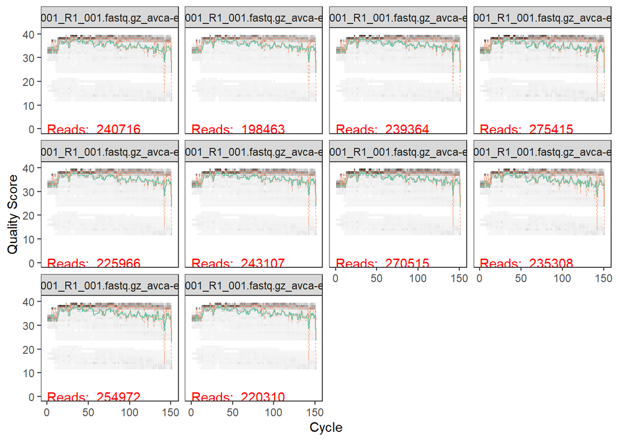

```r
# Inspect quality of sequences in files
plotQualityProfile(fnFs[1:10]) # forward
```

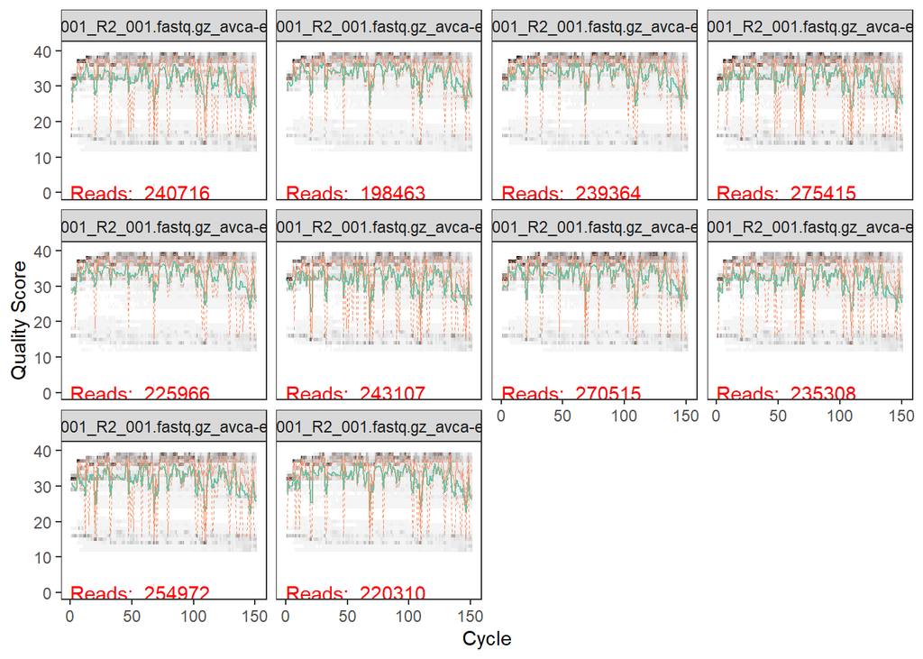

```r
plotQualityProfile(fnRs[1:10]) # reverse
```

- The quality score seems good for the forward reads for the first `140` nucleotides (nt), so I trimmed the first and last `10` nt of the `150`; this is the general recommended practice.
- The quality of the reverse reads seems questionable? Reverse reads are always of lower quality, but these seem especially bad (worse than ones from SBAR and Carlota projects), and there’s not just a certain drop-off point where they become bad. However, “DADA2 incorporates quality information into its error model”, so hopefully this is enough, because at this point I think it relates to the quality of DNA extracted, and I am not going to go back and re-extract.